```
##
## Call:
## lm(formula = price ~ carat + color + clarity + table + x, data = diamonds_cleaned)
##
## Residuals:
##      Min       1Q   Median       3Q      Max
## -21444.5   -599.4   -178.0    391.5  10591.8
##
## Coefficients:
##              Estimate Std. Error t value Pr(>|t|)
## (Intercept) -1388.839    153.570  -9.044   <2e-16 ***
## carat       10945.695     47.878 228.617   <2e-16 ***
## colorE       -210.489     18.146 -11.600   <2e-16 ***
## colorF       -286.752     18.346 -15.630   <2e-16 ***
## colorG       -493.858     17.957 -27.502   <2e-16 ***
## colorH       -993.809     19.090 -52.058   <2e-16 ***
## colorI      -1474.570     21.460 -68.714   <2e-16 ***
## colorJ      -2387.941     26.497 -90.122   <2e-16 ***
## clarityIF    5665.892     51.012 111.070   <2e-16 ***
## claritySI1   3894.266     43.662  89.191   <2e-16 ***
## claritySI2   2926.092     43.916  66.630   <2e-16 ***
## clarityVS1   4845.059     44.522 108.825   <2e-16 ***
## clarityVS2   4528.148     43.829 103.315   <2e-16 ***
## clarityVVS1  5309.983     47.087 112.770   <2e-16 ***
## clarityVVS2  5234.228     45.803 114.277   <2e-16 ***
## table         -32.708      2.266 -14.435   <2e-16 ***
## x            -900.270     20.245 -44.469   <2e-16 ***
## ---
## Signif. codes:  0 '***' 0.001 '**' 0.01 '*' 0.05 '.' 0.1 ' ' 1
##
## Residual standard error: 1146 on 53926 degrees of freedom
## Multiple R-squared:  0.9175, Adjusted R-squared:  0.9174
## F-statistic: 3.746e+04 on 16 and 53926 DF,  p-value: < 2.2e-16
```

### 1. Regression Model Assumptions: Linearity & Constant Error Variance (Homoscedasticity)

#### 1(a) Residual vs Fitted Values Plot

#### 1(b) Response vs Fitted Values Plot

If the LOESS curve is not flat, it suggests non-linearity, which may mean the linear model is misspecified or missing interaction/polynomial terms.

#### 1(c) Response vs Predictors Plot

### 2. Normality of the Errors (Model Fit) Assumption: Histogram & Normal QQ-Plot

#### 2(a) Histogram of Standardized Residuals

#### 2(b) Normal QQ-Plot of Standardized Residuals

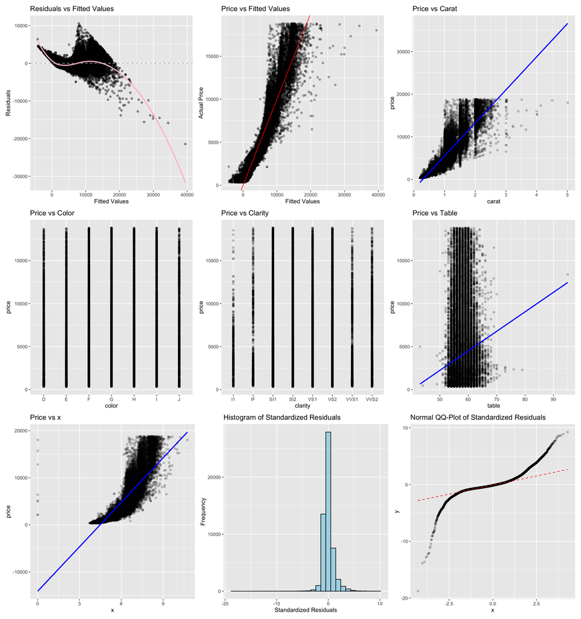

## Preliminary Model Results

To investigate how the carat—price relationship varies across different diamond clarity levels after adjusting for color, table size, and x-dimension (length), we fit a Multiple Linear Regression model: **price ~ carat + color + clarity + table + x**.

Furthermore, the **histogram of standardized residuals** sharply peaked around 0 with heavy tails, and the **normal QQ-plot** confirmed it as it showed deviations at both tails, indicating violations of the normality assumption.

Despite these concerns, the model explains a substantial portion of the variance in price, with an adjusted R^2=0.9174.

The coefficient estimates revealed that **carat** is the strongest numerical predictor: for every additional **carat**, **price** increases by approximately $10,945.695. Among the categorical predictors, diamonds graded as clarityIF (Internally Flawless) are associated with a $5,665.892 higher average price than the base-level (I1), holding other variables constant. Lower **color** grades such as J result in significant price reductions, approximately $2,387.941 less than D.

Interestingly, numerical predictors **table** and **x** showed negative associations with **price**. Holding other variables constant, a 1-unit increase in the **table** value is associated with an estimated $32.708 decrease in **price**. This result is counterintuitive, as diamonds with slightly larger **table** sizes are generally more desirable for their ability to reflect light effectively, so increasing their value. Similarly, a 1-unit increase in the x-dimension corresponds to an estimated $900.27 decrease in **price**, which is also unexpected since longer diamonds are usually more valuable. However, because **x** is strongly correlated with **carat**, this suggests potential multicollinearity—both variables may be capturing similar variance in the data. The large negative coefficient for **x** likely reflects this redundancy. So one might consider centering or removing **x** or replacing it with a composite variable like volume.